# Homework 06

Shushi Meng (shushim2)

## Question 1: KNN and logistic regression

I used seed 432 and a random 70/30 split: 398 training cases and 171 test cases. The same split is used throughout. Means and standard deviations are calculated from the training data only. The positive class is malignant (y = 1).

```
import numpy as np
import matplotlib.pyplot as plt
from sklearn.model_selection import train_test_split
from sklearn.preprocessing import StandardScaler
from sklearn.linear_model import LogisticRegression
from sklearn.neighbors import KNeighborsClassifier
from sklearn.metrics import roc_curve, roc_auc_score

data = np.loadtxt("data/breast-cancer.csv", delimiter=",", skiprows=1)
X, y = data[:, :3], data[:, 3].astype(int)
X_train, X_test, y_train, y_test = train_test_split(
    X, y, test_size=0.3, random_state=432)
scaler = StandardScaler().fit(X_train)
X_train = scaler.transform(X_train)
X_test = scaler.transform(X_test)

# C = infinity removes the penalty; the intercept is fitted.
models = {"Logistic": LogisticRegression(C=np.inf, max_iter=2000, tol=1e-10)}
for k in [5, 15, 25, 35, 45]:
    models[f"KNN k={k}"] = KNeighborsClassifier(
        n_neighbors=k, weights="uniform", metric="euclidean")

q1_rows = []
fig, ax = plt.subplots(figsize=(6, 4.5))
styles = ["-", "--", ":", "-.", "--", ":"]
for (name, model), style in zip(models.items(), styles):
    model.fit(X_train, y_train)
    prob = model.predict_proba(X_test)[:, 1]
    auc = roc_auc_score(y_test, prob)
    q1_rows.append([name, auc])
    fpr, tpr, _ = roc_curve(y_test, prob)
    ax.plot(fpr, tpr, linestyle=style, label=name)
ax.plot([0, 1], [0, 1], "k:", linewidth=0.7)
ax.set(xlabel="False positive rate", ylabel="True positive rate",
       title="Test ROC curves", xlim=(0, 1), ylim=(0, 1.02))
ax.legend(fontsize=8, loc="lower right")
fig.tight_layout()
```

| Model | Test AUC |
| --- | --- |
| Logistic | 0.9822 |
| KNN k=5 | 0.9560 |
| KNN k=15 | 0.9705 |
| KNN k=25 | 0.9784 |
| KNN k=35 | 0.9780 |
| KNN k=45 | 0.9784 |

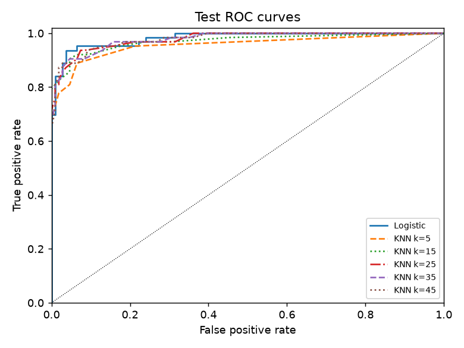

I prefer Logistic for this split because it has the largest test AUC (0.9822). AUC compares ranking across cutoffs; it does not pick a cutoff. This is a comparison on one test split, so I would use cross-validation for tuning and a fresh test set for a final performance estimate.

## Question 2: Training and test ROC curves

```
q2_rows = []
fig, axes = plt.subplots(2, 3, figsize=(10, 6.5))
for ax, k in zip(axes.flat, [1, 3, 5, 10, 20]):
    model = KNeighborsClassifier(n_neighbors=k, weights="uniform", metric="euclidean")
    model.fit(X_train, y_train)
    # Passing X_train explicitly includes each case among its own neighbors.
    p_train = model.predict_proba(X_train)[:, 1]
    p_test = model.predict_proba(X_test)[:, 1]
    a_train = roc_auc_score(y_train, p_train)
    a_test = roc_auc_score(y_test, p_test)
    q2_rows.append([k, a_train, a_test])
    for labels, prob, name, style in [
        (y_train, p_train, "Train", "-"),
        (y_test, p_test, "Test", "--")]:
        fpr, tpr, _ = roc_curve(labels, prob)
        ax.plot(fpr, tpr, style, label=name)
    ax.plot([0, 1], [0, 1], "k:", linewidth=0.7)
    ax.set(title=f"k = {k}", xlabel="False positive rate",
           ylabel="True positive rate", xlim=(0, 1), ylim=(0, 1.02))
    ax.legend(fontsize=8, loc="lower right")
axes.flat[-1].axis("off")
fig.tight_layout()
```

| k | Training AUC | Test AUC |
| --- | --- | --- |
| 1 | 1.0000 | 0.8962 |
| 3 | 0.9929 | 0.9114 |
| 5 | 0.9870 | 0.9560 |
| 10 | 0.9825 | 0.9636 |
| 20 | 0.9788 | 0.9706 |

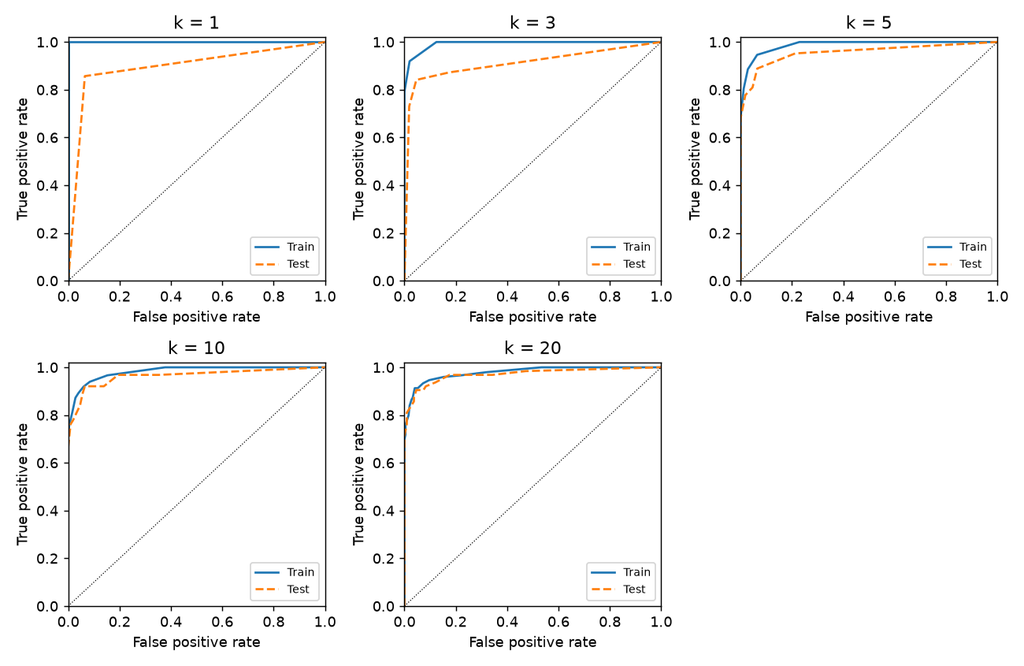

At k = 1, the training AUC is 1.0000, while the test AUC is 0.8962. Each training observation is its own nearest neighbor, so its fitted probability equals its label. That perfect training fit does not carry over to new observations.

Larger k averages more neighbors and makes the predictions less sensitive to individual observations. Training AUC generally falls and the gap becomes smaller, although the test results need not change monotonically. Very large k can smooth away useful local differences. Training predictions reuse the fitted data, so test performance is the more useful check here.

## Question 3: Peer evaluation of Homework 5

I reviewed Urva-Vashi, Homework 5, Question 2(a). I noticed one setting in the KNN code that could be changed.

[Reviewed report](https://github.com/Urva-Vashi/stat432-fall2026/blob/cba8c660393f7835bb3472fccafac782202dd8a9/homework/week-05/homework-05.html)

The current call is:

```
knn_fit = kknn(
    y ~ .,
    train = knn_train,
    test = knn_test,
    k = 5,
    kernel = "rectangular"
  )
```

The rectangular kernel correctly gives equal neighbor weights. However, kknn() uses scale = TRUE by default, while the question asks for Euclidean distance on the original covariate scale. Having population variance one does not mean the sample standard deviations are exactly the same. Rescaling can therefore change the nearest neighbors and the resulting MSE.

I would add scale = FALSE and make the Euclidean distance setting explicit:

```
knn_fit = kknn(
  y ~ ., train = knn_train, test = knn_test,
  k = 5, distance = 2, kernel = "rectangular", scale = FALSE
)
```

After making this change:

1. Rerun both settings using the same seeds and data-generation code, leaving the lasso code unchanged.
2. Recalculate the KNN test MSE values and update the results table.
3. Check whether the comparison with lasso in part (b) still holds, and adjust the explanation if needed.

This change does not necessarily improve the MSE; it makes the fitted model match the question.

[Posted GitHub Issue](https://github.com/Urva-Vashi/stat432-fall2026/issues/2)